# Mini Project 1

Wisdom Uwaifo

2022-07-05

```r
library(readr)
library(tidyverse)
library(ggplot2)
library(dplyr)
library(lubridate)

rats_raw <- read_csv("~/Desktop/Project_Visualization/Mini Project 1/Data/Rat_Sightings.txt", na = c("", "NA", "N/A"))
```

# What story are you telling with your new graphic?

For this first mini-project, I used a column graph to visualize the rat problems in the State of New York. The story behind the column graph is to showcase the prevalence of rat infestation in New York. The column graph shows boroughs’ number of rat sightings from 2010 to 2017. Based on the chart, Brooklyn has the highest number of rat sightings in all the years examined, while Staten Island has the lowest number of rats sighted in all the years represented on the graph. The column graph is critical because it can help individuals planning to move to New York decide on which borough to live in depending on their comfort level with rats infestation.

# How did you apply the principles of CRAP?

CRAP is extremely important in graphic design, and I apply it to every graphic design I make, whether for a class or a personal project. For this first mini-project, I applied CRAP principles in the following ways: - Contrast: I made sure to put items that are the same together and items that are not the same separately. These include typographic contrast, weight contrast, size contrast, and color contrast. - Repeat: - I also ensure that I repeat some aspects of the design throughout the piece. The repetitions include colors, headings or sub-headings, fonts, graphic elements, and alignments. - Every item should have a visual connection with something on the page. Mixing left and right alignment provides stronger contrast. - Lastly, I grouped related items—this is the proximity principle.

# How did you apply Kieran Healy’s principles of great visualizations or Alberto Cairo’s five qualities of great visualizations?

In this mini-project, I applied Alberto Caro’s five qualities of great visualization. These qualities are: - Truthful: The data used for this project is from a reliable source. It was gathered and posted by the State of New York, and the graph is well-plotted to reflect the accurate data and show truthful trends. - Functional: The column graph used for this project is functional because it constitutes the accurate depiction of the data and is built in a way that lets people make meaningful decisions based on it. - Beautiful: I make sure that the graph is esthetically beautiful and attractive. The beauty comes from the combination of colors, alignments, and contrasts. - Insightful: The graph reveals trends and information that people would have had difficulty reading from raw data. Therefore, it is insightful. - Enlightening: The graph tells an entire story that can help people decide where to live in the State of New York.

# Mini Project Codes Below

```r
rats_clean <- rats_raw %>%
  rename(created_date = `Created Date`,
         location_type = `Location Type`,
         borough = Borough) %>%
  mutate(created_date = mdy_hms(created_date)) %>%
  mutate(sighting_year = year(created_date),
         sighting_month = month(created_date),
         sighting_day = day(created_date),
         sighting_weekday = wday(created_date, label = TRUE, abbr = FALSE)) %>%
  filter(borough != "Unspecified")
```

```r
# Count of rats by weekday

rats_clean %>%
  count(sighting_weekday)
```

```
## # A tibble: 7 × 2
##   sighting_weekday     n
##   <ord>            <int>
## 1 Sunday            9084
## 2 Monday           17636
## 3 Tuesday          17507
## 4 Wednesday        17276
## 5 Thursday         16491
## 6 Friday           14581
## 7 Saturday          9338
```

```r
rats_by_borough <- rats_clean %>%
  count(borough, sighting_year)

Rats_by_borough <- ggplot(rats_by_borough, aes(x = fct_rev(borough), y = n, fill = fct_rev(borough))) +
  guides(fill = "none") +
  geom_col() +
  coord_flip() +
  facet_wrap(~ sighting_year)
```

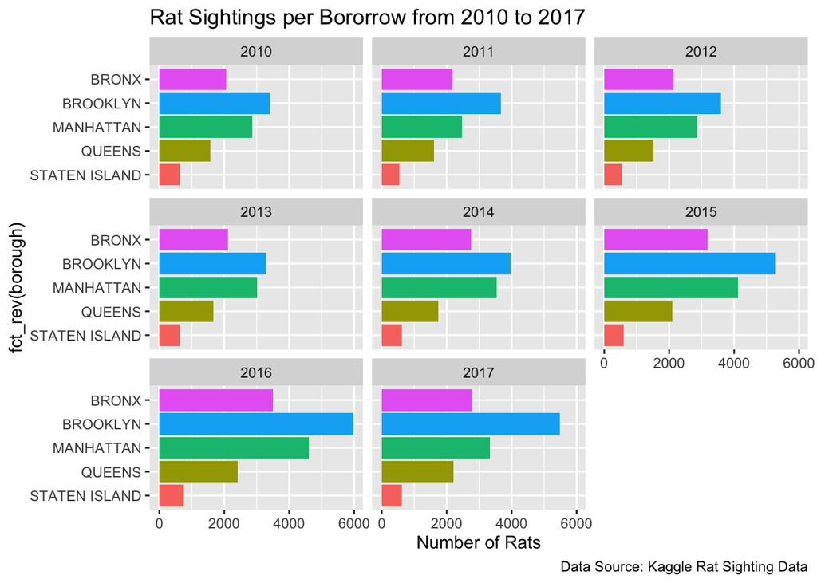

```r
Rats_by_borough +
    labs( y = "Number of Rats",
        color ="borough", size = 2,
        title = "Rat Sightings per Bororrow from 2010 to 2017",
        caption = "Data Source: Kaggle Rat Sighting Data")
```

```r
theme_minimal(base_family = "Roboto Condensed", base_size = 12) +
  theme(panel.grid.minor = element_blank(),
        plot.title = element_text(face = "bold", size = rel(1.7)),
        plot.subtitle = element_text(face = "plain", size = rel(1.3)),
        plot.caption = element_text(face = "italic", size = rel(0.7), color = "grey70", hjust = 0),
        legend.title = element_text(face = "bold"),
        strip.text = element_text(face = "bold", size = rel(1.1), hjust = 0),
        axis.title = element_text(face = "bold"),
        axis.title.x = element_text(margin = margin(t = 10), hjust = 0),
        axis.line.y = element_text(margin = margin(r = 10), hjust = 1)) +
  theme(axis.text.x=element_blank(),
        axis.ticks.x=element_blank()
        )
```

[output not shown]

[output not shown]

```r
ggsave(Rats_by_borough, filename = "Rat_Site_plot.png", width = 8, height = 5)
```

```r
ggsave(Rats_by_borough, filename = "Rat_sightpdf.pdf", width = 8, height = 5)
```